# Version Control With Git

36-350 – Statistical Computing

Week 8 – Fall 2020

# Why Version Control?

“The person who knows the most about your code is you-six-months-ago, and you-six-months-ago are not replying to your emailed questions.” -Anon.

The features of version control:

- It allows you to keep a complete record of changes, allowing you to, e.g., revert back to a previous version of your code if things have gone awry.
- As part of that complete record, it allows you to store messages for every change, so that you can recall the rationale for a change later.
- With, e.g., `Git`, you can back your code up in the cloud (e.g., on `GitHub`), allowing for easy distribution.

Note that here I am talking about “code,” but version control can also be useful when you are, for instance, writing reports (like your DAs in 36-401).

# Git Basics

`Git` allows you to take “snapshots” of the contents of a folder on your machine as you make changes to them. (This is your local repository, or “repo”.) Fix a bug? Take a snapshot. Add functionality? Take a snapshot. These snapshots are dubbed *commits*. Snapshot details are stored in the subfolder .git.

Every time you commit your changes, you write a message that clearly indicates the changes that you have made since your last commit.

In `Git`, two or more people can make independent changes to the same code, or one person can have two or more different code versions being developed in parallel, via *branching*. (Technically a branch is a pointer to a particular commit…think of it as you point to a particular version of a code and “branch out” from there. The default branch is the *main*.) Development spawned by branching can later be *merged*.

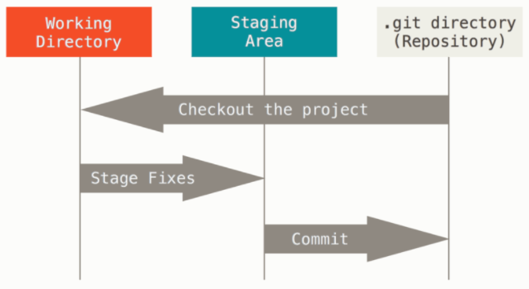

From: *Pro Git* by Chacon & Straub (`git-scm.com/book/en/v2`)

# Install GitHub

1. If you do not have a `GitHub` account, get one at `github.com`!

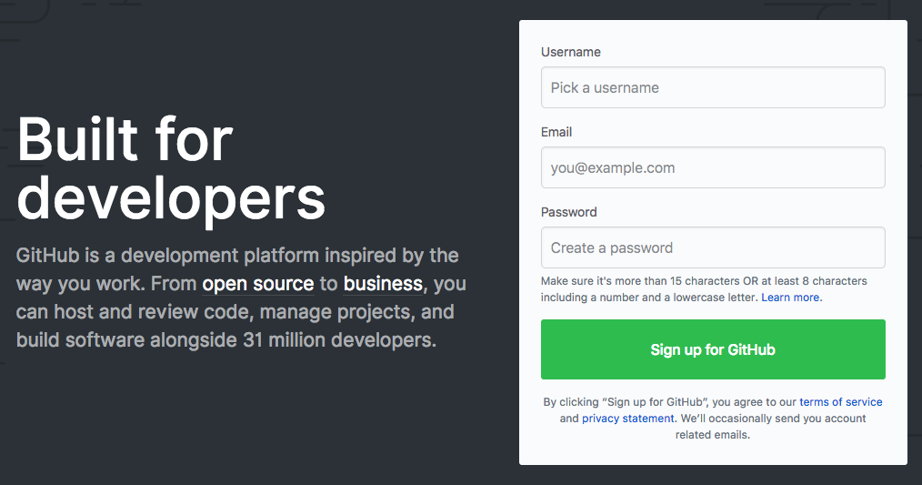

Pick a “professional” user name that hews to your own name as much as possible, and not, e.g., `bozo666` or `partyanimal`. Why? You may be directing potential future employers to your `GitHub` page!

# Install Git

2. If you do not have `Git` installed on your laptop, install it!
- `https://git-scm.com/downloads`

During setup, configure `Git` with your user name (**use your full name, not your Andrew ID**) and your user email (**which should be the same one you used to sign up for your `GitHub` account**).

# GitHub First…

In this class, we will follow the paradigm of “`GitHub` first”. What this means is that when we create a repository, we will create it on `GitHub` first, then link a local repository to it from inside `RStudio`.

In `GitHub`, do the following:

- go to the top-level directory (i.e., `github.com/<your user name here>`)
- click on “+” at top right, and select “New repository”
- name the repository (e.g., “36-350”)
- provide a short description of the repository (don’t leave completely blank!)
- keep the repository public
- click on “Initialize this repository with a README”…there is no need to “Add .gitignore” or “Add a license”
- click on “Create Repository”

# …then RStudio

In `RStudio`, do the following:

- click on `File > New Project...`
- click on “Version Control”, then on “Git” (see below if you have a Mac, however)
- provide the *full* address for the “Repository URL” (including the `https`, etc.; by default, this will provide the name of your local repository)
- make sure “Create project as subdirectory of:” points to where you want to point it (I’d suggest have a `Git` folder, with your project(s) being subdirectories of that folder)
- click on “Create Project”

At this point, you should find that your `Files` pane is listing the files in your local repository, including one ending in `.Rproj` and the `README.md` file that was created on `GitHub`.

**Mac Users!**

The most common error to pop up when opening a new project is that `RStudio` cannot find `git` on your laptop.

To rectify this:

1. Click on `Tools > Global Options` and in the pop-up window, select `Git/SVN`.
2. For `Git executable`, you will probably see `/usr/bin/git`. This usually needs to be `/usr/local/bin/git`.
3. Hit `Browse`. Hit `Command-Shift-g` (all at once) to force a pop-up window, in which you type `/usr/local/bin`. Hit `Go`, and then once the `Finder` window opens, click on `git` and click on `Open`.
4. You will be back in the `Git/SVN` window. Click `Apply`.
5. Quit and restart `RStudio`. Follow the steps at the top of this slide. If you get to the `Repository URL` pane, you will know that you’ve fixed your issue.

# Updating Your Repository

To, e.g., add a new file to your local repository, do the following:

- open the new file as you always would (as an `R Script`, an `R Markdown` file, etc.)
- fill the file with “stuff”
- save the file…at this point, the file name should show up in the `Git` pane next to an “M” symbol (for modified)
- continue to modify the file, or…stage the file for a commit (think of it as: pose it for its snapshot) by clicking on “Staged” in the Git pane
- click on “Commit” in the `Git` pane
- in the new window that opens, add a “Commit message”, then click on the “Commit” button
- click on “Push” to push your changes from your local repo to your `GitHub` repo

Done.

# Branches

When you first push code to your `GitHub` repo, it will exist in the so-called `main` branch. (Up until September 2020, it was called the `master` branch, and older repos establish before October 2020 still feature a `master` branch instead of a `main` one.) You can view this as the “deployable branch,” i.e., the branch that contains the code you wish to release to the world.

If you are, e.g., working alone, then a common workflow is to improve your code in your local `Git` repo, stage, commit, and push to the `main` branch. In other words, you simply overwrite what is on the `main` branch as you improve your code.

However, there is another workflow, one that is particularly relevant if you work in teams, and that is to create non-`main` branches where you can take your (not-yet-ready-to-be-deployed) code in different directions. If you feel that the changes on a branch need to be propagated to the `main` branch code, you merge your changes into the `main` branch code via a “pull request.”

Here is a simple series of steps for creating a new branch via `GitHub` and `RStudio`’s `Git` pane:

1. On `GitHub`: in your repo, you will see a box above the file list that says “Branch: main” with a downward-pointing triangle. Click on this, and in the window that appears, provide a branch name, such as `new_branch`. Hit return. `GitHub` will take you to your new branch. All the code in this branch is the same.
2. In `RStudio`: open your project, and go to the `Git` pane, where you will see the words “New Branch” in the upper-right-hand corner. Click on this, and in the pop-up window that appears, type a branch name. **This should be the same name that you just used in the GitHub repo itself.**
3. In the new branch, you can edit code, and the changes *will only be seen in the new branch itself*. You can stage, commit, and push as before, but your changes will only go to the new branch on `GitHub`.

# Sources of Information

- [Happy Git With R](http://happygitwithr.com) by Jenny Bryan and a squad of TAs
- [An Introduction to Git and How to Use It with RStudio](http://r-bio.github.io/intro-git-rstudio/)
- [Pro Git](https://git-scm.com/book/en/v2) by Scott Chacon & Ben Straub